# Part II - (Dataset Exploration: Loan Data from Prosper)

## Investigation Overview

Some of the variables that I focused on are the LoanStatus, Term, BorrowerAPR, BorrowerRate will be of help in determining the APR for a borrower, factors affecting the the interest rate. Also to determine the loan status we will have to combine variables like LoanOriginalAmount, LoanStatus, EmploymentStatus, IsBorrowerHomeowner. Some of the major questions that were identified to help in the visualization included:

- What factors affect the Borrower's interest rate for this loan?
- What factors affect the Borrower's Annual Percentage Rate (APR) for the loan?
- What are the factors affecting status of the loan?
- If being a home owner affects the borrowing capacity?
- What factors affect the original loan amount?
- What affect the Term limit for a Loan?

## Dataset Overview

Loan Data from Prosper data set contains 113,937 loans with 81 variables on each loan, including loan amount, borrower rate (or interest rate), current loan status, borrower income, and many others.

```python
# import all packages and set plots to be embedded inline
import numpy as np
import pandas as pd
import matplotlib.pyplot as plt
import seaborn as sb
import warnings

from pandas.api.types import CategoricalDtype

warnings.filterwarnings('ignore')
%matplotlib inline
```

```python
# load in the dataset into a pandas dataframe - saved after cleanup
loan = pd.read_csv('prosperLoanData_master.csv')
```

> Note that the above cells have been set as "Skip"-type slides. That means that when the notebook is rendered as http slides, those cells won't show up.

```python
#Confirm Dataset Loading
loan.info()
```

```
<class 'pandas.core.frame.DataFrame'>
RangeIndex: 106312 entries, 0 to 106311
Data columns (total 19 columns):
 #   Column                    Non-Null Count   Dtype
---  ------                    --------------   -----
 0   ListingCreationDate       106312 non-null  object
 1   Term                      106312 non-null  int64
 2   LoanStatus                106312 non-null  object
 3   BorrowerAPR               106312 non-null  float64
 4   BorrowerRate              106312 non-null  float64
 5   LenderYield               106312 non-null  float64
 6   ListingCategory           106312 non-null  object
 7   EmploymentStatus          106312 non-null  object
 8   EmploymentStatusDuration  106312 non-null  int64
 9   IsBorrowerHomeowner       106312 non-null  bool
 10  IncomeRange               106312 non-null  object
 11  IncomeVerifiable          106312 non-null  bool
 12  StatedMonthlyIncome       106312 non-null  float64
 13  LoanOriginalAmount        106312 non-null  int64
 14  LoanOriginationDate       106312 non-null  object
 15  LoanOriginationQuarter    106312 non-null  object
 16  MonthlyLoanPayment        106312 non-null  float64
 17  loanOrigination_month     106312 non-null  int64
 18  loanOrigination_year      106312 non-null  int64
dtypes: bool(2), float64(5), int64(5), object(7)
memory usage: 14.0+ MB
```

```python
#color definition
base_color = sb.color_palette()[0]

base_c1=sb.color_palette()[1]

base_c2=sb.color_palette()[2]
```

```python
# Function for a bar chart (categorical variable)

def barchart_x(i):
    sb.countplot(data = loan, x= i, color=base_color);

def barchart_y(i):
    sb.countplot(data = loan, y= i, color=base_color);
```

```python
#Checking number of parameters and value count for each

count = loan.IsBorrowerHomeowner.value_counts()
print(count)
```

```
True     54905
False    51407
Name: IsBorrowerHomeowner, dtype: int64
```

```python
#Ordering the LoanOriginationQuarter categorical variable
unordered_quarter = ['Q1 2007', 'Q2 2007', 'Q3 2007', 'Q4 2007', 'Q1 2008', 'Q2 2008', 'Q3 2008', 'Q4 2008',
       'Q1 2009', 'Q2 2009', 'Q3 2009', 'Q4 2009', 'Q1 2010', 'Q2 2010', 'Q3 2010', 'Q4 2010',
       'Q1 2011', 'Q2 2011', 'Q3 2011', 'Q4 2011', 'Q1 2012', 'Q2 2012', 'Q3 2012', 'Q4 2012',
       'Q1 2013', 'Q2 2013', 'Q3 2013', 'Q4 2013', 'Q1 2014']
ordered_quarter = CategoricalDtype(categories=unordered_quarter, ordered=True)
loan.LoanOriginationQuarter = loan.LoanOriginationQuarter.astype(ordered_quarter)
```

```python
#Sample random 500 loans so that plots are clearer.
np.random.seed(1)
df_sample = loan.sample(500)
```

## BorrowerAPR Distribution

> BorrowerAPR has 3 peaks (multimodal Distribution) This is observed between the regions:
> - Between 0.15 and 0.2
> - At 0.3
> - Between 0.35 and 0.4

> Other regions remain to be evenly distributed.

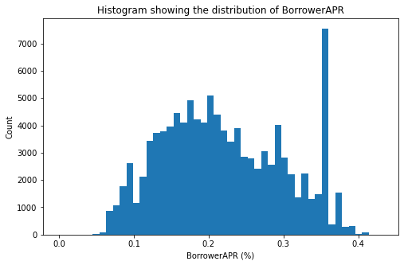

```python
#standard-scaled plot
binsize = 0.009
bins = np.arange(0, loan['BorrowerAPR'].max()+binsize, binsize)

plt.figure(figsize=[8, 5])
plt.hist(data = loan, x = 'BorrowerAPR', bins = bins)
plt.xlabel('BorrowerAPR (%)')
plt.ylabel('Count')
plt.title('Histogram showing the distribution of BorrowerAPR')
plt.show()
```

## BorrowerRate Distribution

> Borrower Interest Rate has a Multimodal Distribution almost similar to that of the BorrowerAPR. This indicates that there is a relationship between this two variables.

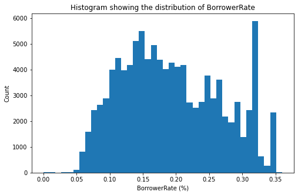

```python
#standard-scaled plot
binsize = 0.009
bins = np.arange(0, loan['BorrowerRate'].max()+binsize, binsize)

plt.figure(figsize=[8, 5])
plt.hist(data = loan, x = 'BorrowerRate', bins = bins)
plt.xlabel('BorrowerRate (%)')
plt.ylabel('Count')
plt.title('Histogram showing the distribution of BorrowerRate')
plt.show()
```

## LoanOriginationQuarter, loanOrigination_year, loanOrigination_month

> More loan borrowers in 2013 as compared to other year. 2009 had the lowest loan borrowers.

> We have more borrowers in the months of October, November, December and January. Less borrowers in the month of April.

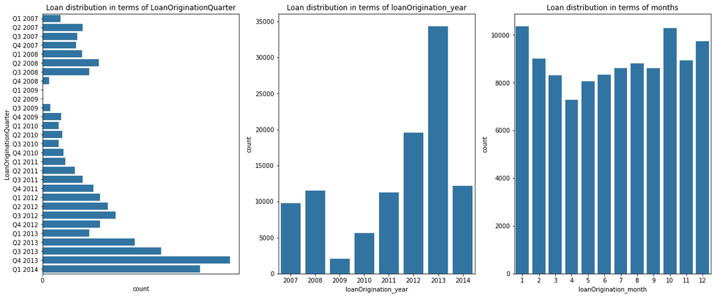

```python
plt.figure(figsize=[20,8])
plt.subplot(1,3,1)
sb.countplot().set_title('Loan distribution in terms of LoanOriginationQuarter');
barchart_y('LoanOriginationQuarter')

plt.subplot(1,3,2)
sb.countplot().set_title('Loan distribution in terms of loanOrigination_year');
barchart_x('loanOrigination_year')


plt.subplot(1,3,3)
sb.countplot().set_title('Loan distribution in terms of months');
barchart_x('loanOrigination_month')


plt.show();
```

## Loan Distribution

- Distribution is into 3 parts (12 months, 36 months and 60 months)
- More loans prefered with a term of 36months than 12 or 60 months

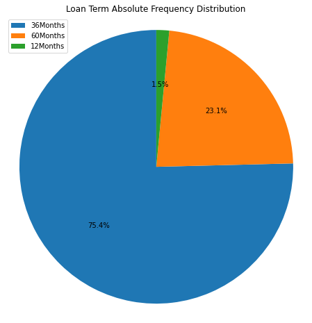

```python
plt.figure(figsize=[8,8])
period = loan.Term.value_counts()
labels = '36Months','60Months','12Months'
plt.pie(period, autopct='%1.1f%%', startangle=90)
plt.title('Loan Term Absolute Frequency Distribution')
plt.axis('square')
plt.legend(labels);
```

## HomeOwnership Effect on BorrowerRate/ BorrowerAPR

- 51.6% of home owners are loan borrowers compared to 48.4% who don't own a home. This small margin means that this variable is not a good determinant to tell whether those who are loan borrowers home owners or not.

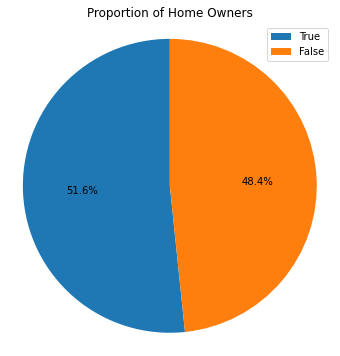

```python
plt.figure(figsize=[8,6])
labels=count.index
plt.pie(count, autopct='%1.1f%%', startangle=90)
plt.axis('square')
plt.title('Proportion of Home Owners')
plt.legend(labels);
```

## LoanOriginalAmount, Term vs BorrowerRate

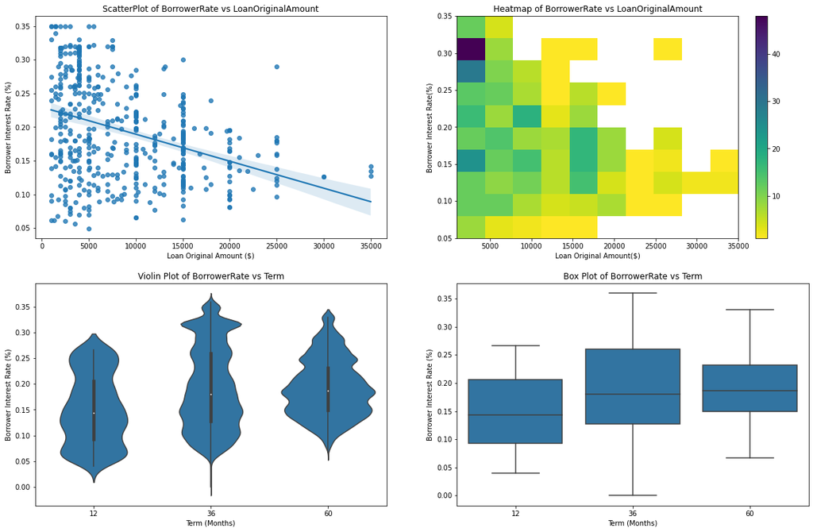

```python
plt.figure(figsize=[20,13])

#Creating ScatterPlot for LoanOriginalAmount, BorrowerRate
plt.subplot(2,2,1)
sb.regplot(data=df_sample, y='BorrowerRate', x='LoanOriginalAmount')
plt.ylabel('Borrower Interest Rate (%)')
plt.xlabel('Loan Original Amount ($)')
plt.title('ScatterPlot of BorrowerRate vs LoanOriginalAmount');

#Creating Heatmap for LoanOriginalAmount, BorrowerRate
plt.subplot(2,2,2)
plt.hist2d(data=df_sample,  y='BorrowerRate', x='LoanOriginalAmount', cmap='viridis_r', cmin=0.5)
plt.ylabel('Borrower Interest Rate(%)')
plt.xlabel('Loan Original Amount($)')
plt.title('Heatmap of BorrowerRate vs LoanOriginalAmount');
plt.colorbar();

#Creating Violin plot for Term, BorrowerRate
plt.subplot(2,2,3)
sb.violinplot(data=loan, y='BorrowerRate', x='Term',color=base_color)
plt.ylabel('Borrower Interest Rate (%)')
plt.xlabel('Term (Months)')
plt.title('Violin Plot of BorrowerRate vs Term');

#Creating Boxplot for Term, BorrowerRate
plt.subplot(2,2,4)
sb.boxplot(data=loan,  y='BorrowerRate', x='Term',color=base_color)
plt.ylabel('Borrower Interest Rate (%)')
plt.xlabel('Term (Months)')
plt.title('Box Plot of BorrowerRate vs Term');
```

## Correlation of numerical variable using heat map

- BorrowerAPR is highly correlated with BorrowerRate.
- When BorrowerAPR increases, BorrowerRate increases and vice versa is true.
- There is a negative correlation between LoanOriginalAmount vs BorrowerRate/BorrowerAPR.

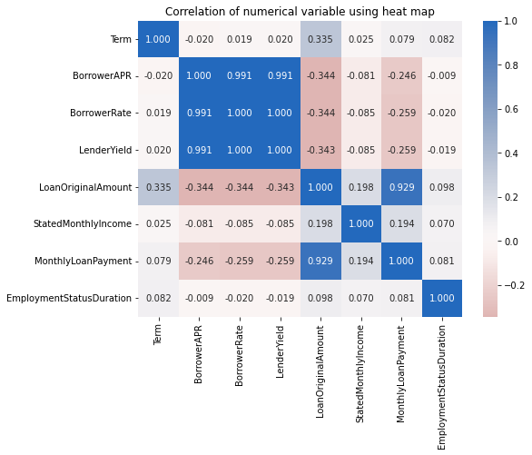

```python
#Listing of numerical variables
num_vars = ['Term','BorrowerAPR','BorrowerRate','LenderYield','LoanOriginalAmount',
            'StatedMonthlyIncome','MonthlyLoanPayment','EmploymentStatusDuration']

#Correlation plot
plt.figure(figsize = [8, 6])
sb.heatmap(loan[num_vars].corr(), annot = True, fmt = '.3f',
           cmap = 'vlag_r', center = 0)
plt.title('Correlation of numerical variable using heat map');
plt.show()
```

## LoanStatus vs Term

- Completed Status: High count of Loans with Term of 36months fall in this category compared to a small count in 12month term.
- Defaulted: Most of the loans defaulted fall in the Term of 36months.
- Past Due: Small counts fall in the due category but mostly loan in the Term of 36months.
- FinalPaymentInProgress - Small count which lies in the Term of 36months.

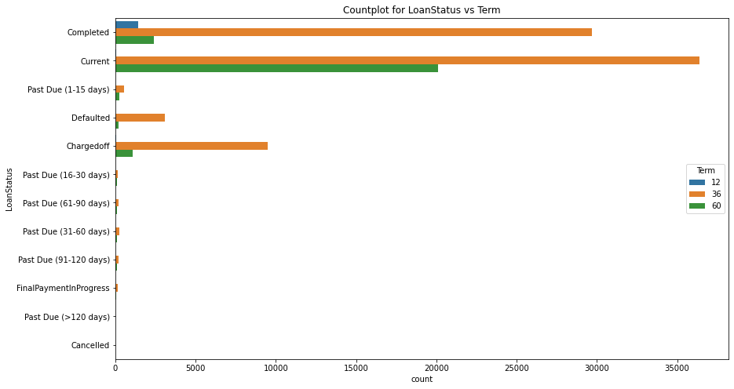

```python
#Countplot for LoanStatus vs Term

plt.figure(figsize=[14,8])
sb.countplot(data=loan, y='LoanStatus', hue='Term').set_title('Countplot for LoanStatus vs Term');
```

## LoanOriginalAmount vs BorrowerAPR

- BorrowerAPR count highest between 1000 and 7000.
- We have a negative correlation between BorrowerAPR and LoanOriginalAmount. As LoanOriginalAmount increases, BorrowerAPR is decreasing and BorrowerAPR count is decreasing significantly after 16,000.
- When LoanOriginalAmount between 1000 - 7000 highest count of BorrowerAPR is 6706 at approximately 0.35.

It can be noted that when LoanOriginalAmount is small it has more borrowers and very high BorrowerAPR.

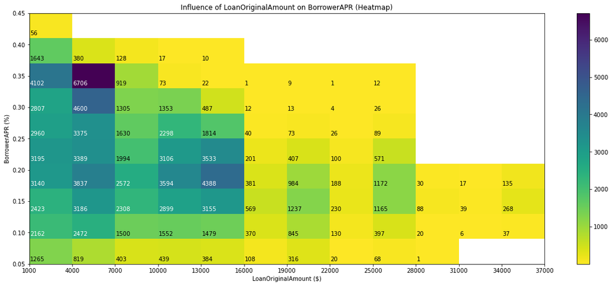

```python
#Plotting Influence of LoanOriginalAmount on BorrowerAPR (Heatmap)
plt.figure(figsize=(20,8))
bins_x = np.arange(1000,35000+5000,3000)
bins_y=np.arange(0.05,0.40+0.06,0.04)
labels = ['{}'.format(x) for x in bins_x]
gt = plt.hist2d(y='BorrowerAPR',x='LoanOriginalAmount',data=loan,cmin=0.5,cmap='viridis_r',bins=[bins_x,bins_y])
count = gt[0]
for i in range(count.shape[0]):
    for j in range(count.shape[1]):
        annot = count[i,j]
        if annot!=np.nan and annot >= 2000:
            plt.text(x=gt[1][i]+50,y=gt[2][j]+0.005,s=int(annot),color='white')
        elif annot !=np.nan and annot > 0:
             plt.text(x=gt[1][i]+50,y=gt[2][j]+0.005,s=int(annot),color='black')
plt.colorbar()
plt.xticks(bins_x,labels)
plt.title('Influence of LoanOriginalAmount on BorrowerAPR (Heatmap)')
plt.xlabel('LoanOriginalAmount ($)')
plt.ylabel('BorrowerAPR (%)');
```

## BorrowerAPR, BorrowerRate, EmploymentStatus.

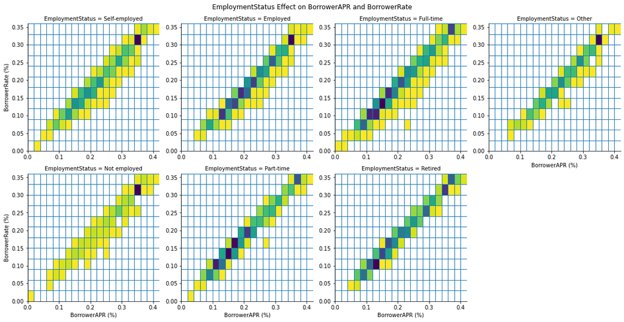

```python
#Heatmap for BorrowerAPR, BorrowerRate, EmploymentStatus.
bins_x = np.arange(0,loan['BorrowerAPR'].max()+0.01,0.02)
bins_y = np.arange(0,loan['BorrowerRate'].max()+0.01,0.03)
g = sb.FacetGrid(data = loan, col = 'EmploymentStatus', sharex=False,sharey=False,col_wrap = 4, height = 4)
g.map(plt.hist2d, 'BorrowerAPR', 'BorrowerRate',bins=[bins_x,bins_y], cmap = 'viridis_r', cmin = 0.5)
g.set_xlabels('BorrowerAPR (%)')
g.set_ylabels('BorrowerRate (%)')

g.fig.suptitle('EmploymentStatus Effect on BorrowerAPR and BorrowerRate',y=1.02)
plt.show()
```

## BorrowerAPR, LoanStatus, Term

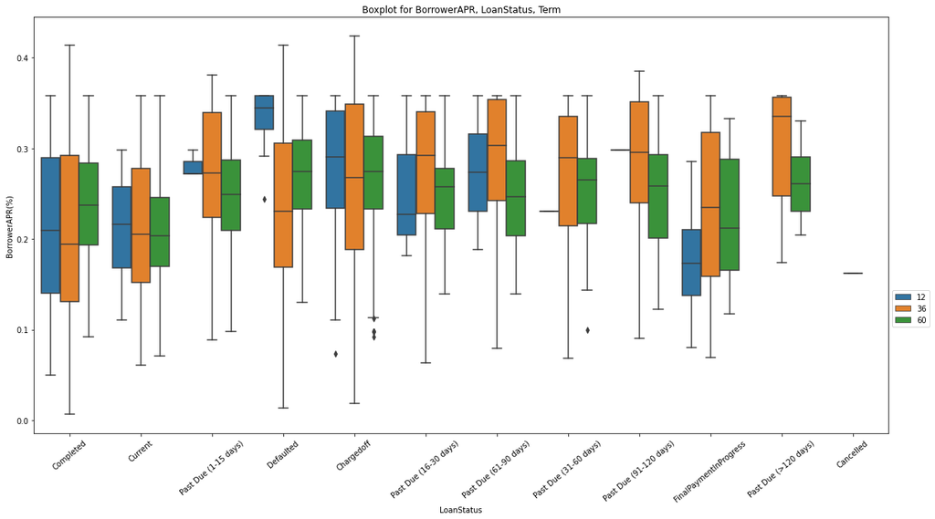

```python
plt.figure(figsize=[20,10])
sb.boxplot(data = loan, y = 'BorrowerAPR', x = 'LoanStatus',
           hue = 'Term').set_title('Boxplot for BorrowerAPR, LoanStatus, Term')
plt.legend(loc = 6, bbox_to_anchor = (1, 0.3))
plt.ylabel('BorrowerAPR(%)')
plt.xticks(rotation = 40);
```

```python
!jupyter nbconvert Part_II_slide_deck_template.ipynb --to slides --post serve --no-input --no-prompt
```

```
[NbConvertApp] Converting notebook Part_II_slide_deck_template.ipynb to slides
[NbConvertApp] Writing 1099003 bytes to Part_II_slide_deck_template.slides.html
[NbConvertApp] Redirecting reveal.js requests to https://cdnjs.cloudflare.com/ajax/libs/reveal.js/3.5.0
Serving your slides at http://127.0.0.1:8000/Part_II_slide_deck_template.slides.html
Use Control-C to stop this server
^C

Interrupted
```